# Ch.3 Describnig Data

# Chapter 3: Describing Data

## building the base dataset

we are going to be building a base dat aset,

```r
## there will be 20 stores
k.stores = 20
##with two years worth of dat
k.weeks = 104

###creating the base data frame
store.df = data.frame(matrix(NA, ncol = 10, nrow = k.stores*k.weeks))
###naming the files
names(store.df) = c("store_nbr", "Yr","Wk","p1_sales", "p2_sales","p1_price","p2_price", "p1_prom","p2_prom", "country")


dim(store.df)
```

```
## [1] 2080   10
```

```r
head(store.df)
```

```
##   store_nbr Yr Wk p1_sales p2_sales p1_price p2_price p1_prom p2_prom
## 1        NA NA NA       NA       NA       NA       NA      NA      NA
## 2        NA NA NA       NA       NA       NA       NA      NA      NA
## 3        NA NA NA       NA       NA       NA       NA      NA      NA
## 4        NA NA NA       NA       NA       NA       NA      NA      NA
## 5        NA NA NA       NA       NA       NA       NA      NA      NA
## 6        NA NA NA       NA       NA       NA       NA      NA      NA
##   country
## 1      NA
## 2      NA
## 3      NA
## 4      NA
## 5      NA
## 6      NA
```

```r
tail(store.df)
```

```
##      store_nbr Yr Wk p1_sales p2_sales p1_price p2_price p1_prom p2_prom
## 2075        NA NA NA       NA       NA       NA       NA      NA      NA
## 2076        NA NA NA       NA       NA       NA       NA      NA      NA
## 2077        NA NA NA       NA       NA       NA       NA      NA      NA
## 2078        NA NA NA       NA       NA       NA       NA      NA      NA
## 2079        NA NA NA       NA       NA       NA       NA      NA      NA
## 2080        NA NA NA       NA       NA       NA       NA      NA      NA
##      country
## 2075      NA
## 2076      NA
## 2077      NA
## 2078      NA
## 2079      NA
## 2080      NA
```

as you can see, most of the data is empty in this data frame, let’s populating the store number and the country code

```r
store.num = 1:k.stores
store.cty = c(rep('US',3),
                            rep("DE",5),
                            rep("GB",3),
                            rep("BR",2),
                            rep("JP",4),
                            rep("AU",1),
                            rep("CN",2))

store.df$store_nbr = rep(store.num, each = k.weeks)
store.df$country = rep(store.cty, each = k.weeks)

store.df$store_nbr = factor(store.df$store_nbr)
store.df$country = factor(store.df$country)



head(store.df)
```

```
##   store_nbr Yr Wk p1_sales p2_sales p1_price p2_price p1_prom p2_prom
## 1         1 NA NA       NA       NA       NA       NA      NA      NA
## 2         1 NA NA       NA       NA       NA       NA      NA      NA
## 3         1 NA NA       NA       NA       NA       NA      NA      NA
## 4         1 NA NA       NA       NA       NA       NA      NA      NA
## 5         1 NA NA       NA       NA       NA       NA      NA      NA
## 6         1 NA NA       NA       NA       NA       NA      NA      NA
##   country
## 1      US
## 2      US
## 3      US
## 4      US
## 5      US
## 6      US
```

```r
tail(store.df)
```

```
##      store_nbr Yr Wk p1_sales p2_sales p1_price p2_price p1_prom p2_prom
## 2075        20 NA NA       NA       NA       NA       NA      NA      NA
## 2076        20 NA NA       NA       NA       NA       NA      NA      NA
## 2077        20 NA NA       NA       NA       NA       NA      NA      NA
## 2078        20 NA NA       NA       NA       NA       NA      NA      NA
## 2079        20 NA NA       NA       NA       NA       NA      NA      NA
## 2080        20 NA NA       NA       NA       NA       NA      NA      NA
##      country
## 2075      CN
## 2076      CN
## 2077      CN
## 2078      CN
## 2079      CN
## 2080      CN
```

Now week and Year

```r
store.df$Wk = rep(1:52, times = k.stores*2)
store.df$Yr = rep(rep(1:2, each = k.weeks/2), times = k.stores)

head(store.df)
```

```
##   store_nbr Yr Wk p1_sales p2_sales p1_price p2_price p1_prom p2_prom
## 1         1  1  1       NA       NA       NA       NA      NA      NA
## 2         1  1  2       NA       NA       NA       NA      NA      NA
## 3         1  1  3       NA       NA       NA       NA      NA      NA
## 4         1  1  4       NA       NA       NA       NA      NA      NA
## 5         1  1  5       NA       NA       NA       NA      NA      NA
## 6         1  1  6       NA       NA       NA       NA      NA      NA
##   country
## 1      US
## 2      US
## 3      US
## 4      US
## 5      US
## 6      US
```

```r
tail(store.df)
```

```
##      store_nbr Yr Wk p1_sales p2_sales p1_price p2_price p1_prom p2_prom
## 2075        20  2 47       NA       NA       NA       NA      NA      NA
## 2076        20  2 48       NA       NA       NA       NA      NA      NA
## 2077        20  2 49       NA       NA       NA       NA      NA      NA
## 2078        20  2 50       NA       NA       NA       NA      NA      NA
## 2079        20  2 51       NA       NA       NA       NA      NA      NA
## 2080        20  2 52       NA       NA       NA       NA      NA      NA
##      country
## 2075      CN
## 2076      CN
## 2077      CN
## 2078      CN
## 2079      CN
## 2080      CN
```

Now that all predetermined factors have been populated, lets create some random price and promotion deatils

```r
set.seed(98250)

store.df$p1_prom = rbinom(n=nrow(store.df), size =1, p = 0.1) #10% get promoted
store.df$p2_prom = rbinom(n=nrow(store.df), size = 1, p = 0.15) #15% get promotions

###prices are randomly drawn from five diffrent buckets

store.df$p1_price = sample(x=c(2.19,2.29,2.49,2.79,2.99), size = nrow(store.df), replace = T)
store.df$p2_price = sample(x = c(2.29,2.49,2.59,2.99,3.19), size = nrow(store.df), replace = T)

head(store.df)
```

```
##   store_nbr Yr Wk p1_sales p2_sales p1_price p2_price p1_prom p2_prom
## 1         1  1  1       NA       NA     2.29     2.29       0       0
## 2         1  1  2       NA       NA     2.49     2.49       0       0
## 3         1  1  3       NA       NA     2.99     2.99       1       0
## 4         1  1  4       NA       NA     2.99     3.19       0       0
## 5         1  1  5       NA       NA     2.49     2.59       0       1
## 6         1  1  6       NA       NA     2.79     2.49       0       0
##   country
## 1      US
## 2      US
## 3      US
## 4      US
## 5      US
## 6      US
```

```r
tail(store.df)
```

```
##      store_nbr Yr Wk p1_sales p2_sales p1_price p2_price p1_prom p2_prom
## 2075        20  2 47       NA       NA     2.49     2.59       0       0
## 2076        20  2 48       NA       NA     2.49     2.99       0       0
## 2077        20  2 49       NA       NA     2.49     2.59       0       0
## 2078        20  2 50       NA       NA     2.99     2.29       0       0
## 2079        20  2 51       NA       NA     2.99     2.29       0       0
## 2080        20  2 52       NA       NA     2.49     2.49       0       0
##      country
## 2075      CN
## 2076      CN
## 2077      CN
## 2078      CN
## 2079      CN
## 2080      CN
```

Now generating some sales data, but we are going to base it on the number of items bought first. So we are using a poisson disributios to determine how many units were bought. from there we will determine the total sales based on the log ratio of the item price!

Then we are going to assume a certain amount of lift for promotions

```r
store.df$p1_sales = rpois(nrow(store.df), lambda = 120) * log(store.df$p2_price)/log(store.df$p1_price)
store.df$p2_sales = rpois(nrow(store.df), lambda = 100) * log(store.df$p1_price)/log(store.df$p2_price)

store.df$p1_sales = floor(store.df$p1_sales * (1 + store.df$p1_prom * 0.3)) #30% lift
store.df$p2_sales = floor(store.df$p2_sales * (1 + store.df$p2_prom * 0.4)) #40% lift

head(store.df)
```

```
##   store_nbr Yr Wk p1_sales p2_sales p1_price p2_price p1_prom p2_prom
## 1         1  1  1      127      106     2.29     2.29       0       0
## 2         1  1  2      137      105     2.49     2.49       0       0
## 3         1  1  3      156       97     2.99     2.99       1       0
## 4         1  1  4      117      106     2.99     3.19       0       0
## 5         1  1  5      138      100     2.49     2.59       0       1
## 6         1  1  6      115      127     2.79     2.49       0       0
##   country
## 1      US
## 2      US
## 3      US
## 4      US
## 5      US
## 6      US
```

```r
tail(store.df)
```

```
##      store_nbr Yr Wk p1_sales p2_sales p1_price p2_price p1_prom p2_prom
## 2075        20  2 47      140      104     2.49     2.59       0       0
## 2076        20  2 48      150       88     2.49     2.99       0       0
## 2077        20  2 49      121       97     2.49     2.59       0       0
## 2078        20  2 50       91      124     2.99     2.29       0       0
## 2079        20  2 51       83      115     2.99     2.29       0       0
## 2080        20  2 52      136       99     2.49     2.49       0       0
##      country
## 2075      CN
## 2076      CN
## 2077      CN
## 2078      CN
## 2079      CN
## 2080      CN
```

```r
require(car)
some(store.df, 10) #randomly samples 10 records
```

```
##      store_nbr Yr Wk p1_sales p2_sales p1_price p2_price p1_prom p2_prom
## 27           1  1 27      135       99     2.29     2.49       0       0
## 144          2  1 40      123      113     2.79     2.59       0       0
## 474          5  2  6      114       98     2.49     2.49       0       0
## 488          5  2 20       92      127     2.79     2.29       0       0
## 1036        10  2 48      134      109     2.99     2.29       1       0
## 1554        15  2 46      142       87     2.29     2.59       0       0
## 1565        16  1  5      186       63     2.19     3.19       0       0
## 1585        16  1 25      121      124     2.49     2.29       0       0
## 1944        19  2 20      150       90     2.19     2.29       0       0
## 1966        19  2 42      167       80     2.19     2.49       0       0
##      country
## 27        US
## 144       US
## 474       DE
## 488       DE
## 1036      GB
## 1554      JP
## 1565      JP
## 1585      JP
## 1944      CN
## 1966      CN
```

### Summary

okay, so what did we do:

1. we first created a dataframe that consists of 10 columns, and assumed that there were 20 stores, with data for each week for 2 years (20 stores x 52 weeks per store x 2 years per week) = 2080 rows of per data frame
2. then we created a store number (1 ~ 20) and populated for each week and generated country codes per stores
3. similary genereated year and weeks
4. we generated a binomail distrubion of IF there was a promotion, then randoml sampled from five price points for each product
5. now this gets trick, we created sales data and we did this in three steps 5.1) we generated a count of sales per week (using a poisson distribution) 5.2) multiple by the inverse log ratio of the price point. The reason for this was so if the other item had a higher price, then this items would sell just slightly more…just slightly (remeber, it’s the log ratio, not the ratio) 5.3) if there was a promotion, it lifted sales by 30 or 40% and this gave us the number of items sold!

## Summarizing dat

lets take a look at some basic frequency counts

```r
table(store.df$p1_price)
```

```
##
## 2.19 2.29 2.49 2.79 2.99
##  395  444  423  443  375
```

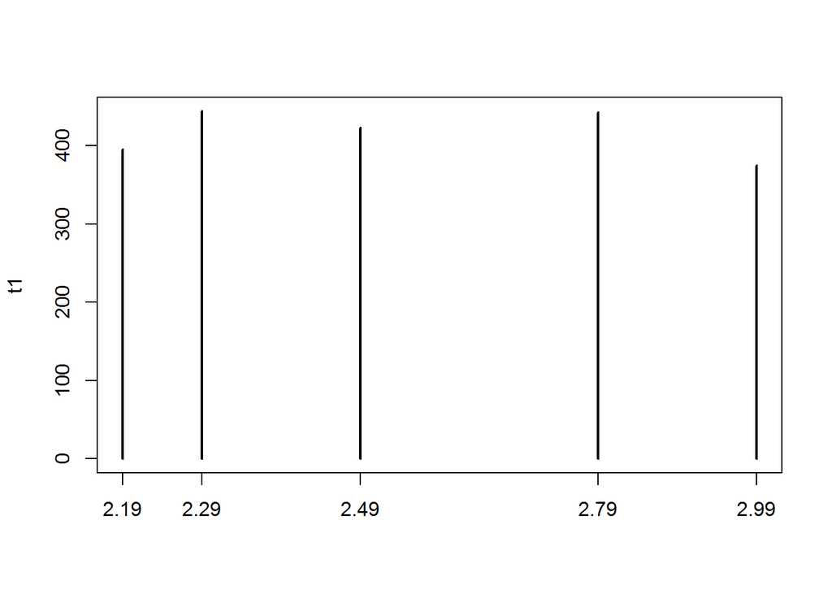

```r
t1 = table(store.df$p1_price)

plot(t1)
```

```r
#### for two variables frequency counts at a time
table(store.df$p1_price, store.df$p1_prom)
```

```
##
##          0   1
##   2.19 354  41
##   2.29 398  46
##   2.49 381  42
##   2.79 396  47
##   2.99 343  32
```

```r
t2 = table(store.df$p1_price, store.df$p1_prom)

t2[,2]/(rowSums(t2))
```

```
##       2.19       2.29       2.49       2.79       2.99
## 0.10379747 0.10360360 0.09929078 0.10609481 0.08533333
```

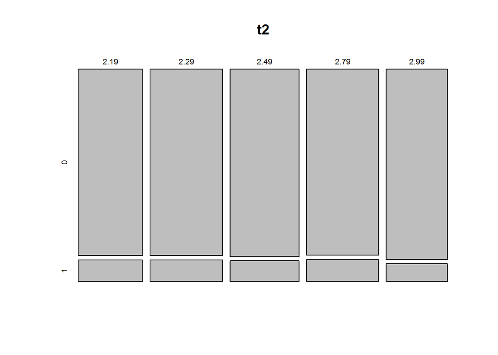

```r
plot(t2)
```

so, what happens if the variable is continues, well…we got some nice functions for that. Generally speaking (and this is c talking) I love to use the summary command

```r
min(store.df$p1_sales)
```

```
## [1] 73
```

```r
max(store.df$p2_sales)
```

```
## [1] 225
```

```r
mean(store.df$p1_prom)
```

```
## [1] 0.1
```

```r
median(store.df$p2_sales)
```

```
## [1] 96
```

```r
var(store.df$p1_sales)
```

```
## [1] 805.0044
```

```r
sd(store.df$p1_sales)
```

```
## [1] 28.3726
```

```r
IQR(store.df$p1_sales)
```

```
## [1] 37
```

```r
mad(store.df$p1_sales)
```

```
## [1] 26.6868
```

```r
quantile(store.df$p1_sales, probs = seq(0.1, 1, by =0.1))
```

```
##   10%   20%   30%   40%   50%   60%   70%   80%   90%  100%
## 100.0 109.0 117.0 122.6 129.0 136.0 145.0 156.0 171.0 263.0
```

```r
summary(store.df)
```

```
##    store_nbr          Yr            Wk           p1_sales
##  1      : 104   Min.   :1.0   Min.   : 1.00   Min.   : 73
##  2      : 104   1st Qu.:1.0   1st Qu.:13.75   1st Qu.:113
##  3      : 104   Median :1.5   Median :26.50   Median :129
##  4      : 104   Mean   :1.5   Mean   :26.50   Mean   :133
##  5      : 104   3rd Qu.:2.0   3rd Qu.:39.25   3rd Qu.:150
##  6      : 104   Max.   :2.0   Max.   :52.00   Max.   :263
##  (Other):1456
##     p2_sales        p1_price        p2_price       p1_prom
##  Min.   : 51.0   Min.   :2.190   Min.   :2.29   Min.   :0.0
##  1st Qu.: 84.0   1st Qu.:2.290   1st Qu.:2.49   1st Qu.:0.0
##  Median : 96.0   Median :2.490   Median :2.59   Median :0.0
##  Mean   :100.2   Mean   :2.544   Mean   :2.70   Mean   :0.1
##  3rd Qu.:113.0   3rd Qu.:2.790   3rd Qu.:2.99   3rd Qu.:0.0
##  Max.   :225.0   Max.   :2.990   Max.   :3.19   Max.   :1.0
##
##     p2_prom       country
##  Min.   :0.0000   AU:104
##  1st Qu.:0.0000   BR:208
##  Median :0.0000   CN:208
##  Mean   :0.1385   DE:520
##  3rd Qu.:0.0000   GB:312
##  Max.   :1.0000   JP:416
##                   US:312
```

```r
summary(store.df, digits = 2) #cool litte feature to keep 2 SIGNIFICANT digits, not two digits after the decimal
```

```
##    store_nbr          Yr            Wk        p1_sales      p2_sales
##  1      : 104   Min.   :1.0   Min.   : 1   Min.   : 73   Min.   : 51
##  2      : 104   1st Qu.:1.0   1st Qu.:14   1st Qu.:113   1st Qu.: 84
##  3      : 104   Median :1.5   Median :26   Median :129   Median : 96
##  4      : 104   Mean   :1.5   Mean   :26   Mean   :133   Mean   :100
##  5      : 104   3rd Qu.:2.0   3rd Qu.:39   3rd Qu.:150   3rd Qu.:113
##  6      : 104   Max.   :2.0   Max.   :52   Max.   :263   Max.   :225
##  (Other):1456
##     p1_price      p2_price      p1_prom       p2_prom     country
##  Min.   :2.2   Min.   :2.3   Min.   :0.0   Min.   :0.00   AU:104
##  1st Qu.:2.3   1st Qu.:2.5   1st Qu.:0.0   1st Qu.:0.00   BR:208
##  Median :2.5   Median :2.6   Median :0.0   Median :0.00   CN:208
##  Mean   :2.5   Mean   :2.7   Mean   :0.1   Mean   :0.14   DE:520
##  3rd Qu.:2.8   3rd Qu.:3.0   3rd Qu.:0.0   3rd Qu.:0.00   GB:312
##  Max.   :3.0   Max.   :3.2   Max.   :1.0   Max.   :1.00   JP:416
##                                                           US:312
```

that is from the base package, which is nice, but the psych package has something intresting

```r
require(psych)
describe(store.df)
```

```
##            vars    n   mean    sd median trimmed   mad   min    max range
## store_nbr*    1 2080  10.50  5.77  10.50   10.50  7.41  1.00  20.00  19.0
## Yr            2 2080   1.50  0.50   1.50    1.50  0.74  1.00   2.00   1.0
## Wk            3 2080  26.50 15.01  26.50   26.50 19.27  1.00  52.00  51.0
## p1_sales      4 2080 133.05 28.37 129.00  131.08 26.69 73.00 263.00 190.0
## p2_sales      5 2080 100.16 24.42  96.00   98.05 22.24 51.00 225.00 174.0
## p1_price      6 2080   2.54  0.29   2.49    2.53  0.44  2.19   2.99   0.8
## p2_price      7 2080   2.70  0.33   2.59    2.69  0.44  2.29   3.19   0.9
## p1_prom       8 2080   0.10  0.30   0.00    0.00  0.00  0.00   1.00   1.0
## p2_prom       9 2080   0.14  0.35   0.00    0.05  0.00  0.00   1.00   1.0
## country*     10 2080   4.55  1.72   4.50    4.62  2.22  1.00   7.00   6.0
##             skew kurtosis   se
## store_nbr*  0.00    -1.21 0.13
## Yr          0.00    -2.00 0.01
## Wk          0.00    -1.20 0.33
## p1_sales    0.74     0.66 0.62
## p2_sales    0.99     1.51 0.54
## p1_price    0.28    -1.44 0.01
## p2_price    0.32    -1.40 0.01
## p1_prom     2.66     5.10 0.01
## p2_prom     2.09     2.38 0.01
## country*   -0.29    -0.81 0.04
```

pretty cool eh:

### recommend approach to instpecting data

1. import data
2. convert to df
3. look at the diminesions by dim()
4. use head() and tail() to investigate the data, generally this is where errors may show up
5. use some() from the car package to randomly investiage rows
6. use str() to check the data structure
7. use summary() and descrip() (from the psych package)

## visualizing data

okay, the easast way to see datat is to look at it. for single variables, a histogram is a great tool

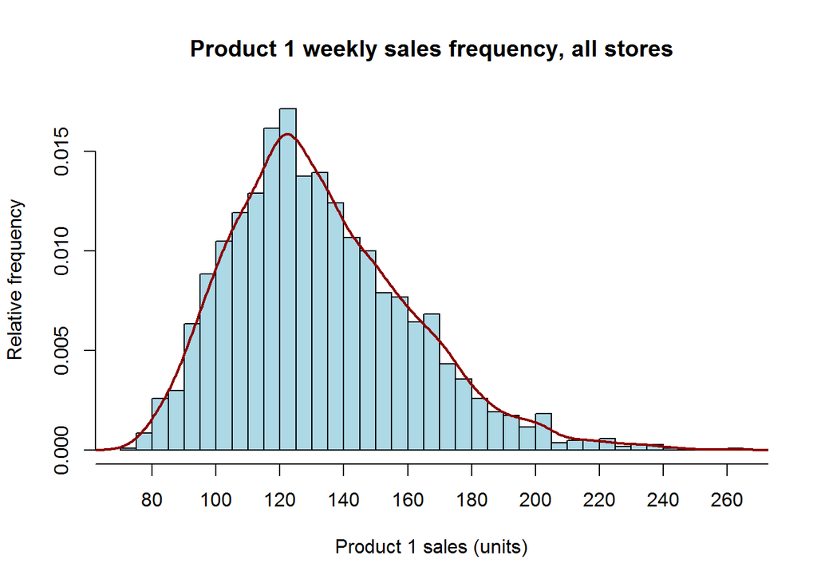

```r
hist(store.df$p1_sales,        #the variable in questions
         main = "Product 1 weekly sales frequency, all stores",
         xlab = "Product 1 sales (units)",
         ylab = "Relative frequency",
         breaks = 30, #we want 30 buclets
         col = "lightblue",
         freq = F, #we don't want counts
         xaxt = "n"
)

axis(side = 1, at = seq(60, 300, by =20)) ##adding the right tick marks

lines(density(store.df$p1_sales, bw = 5), type = "l", col = "darkred", lwd = 2)
```

as well as boxplot to measure a category and contiious variables together

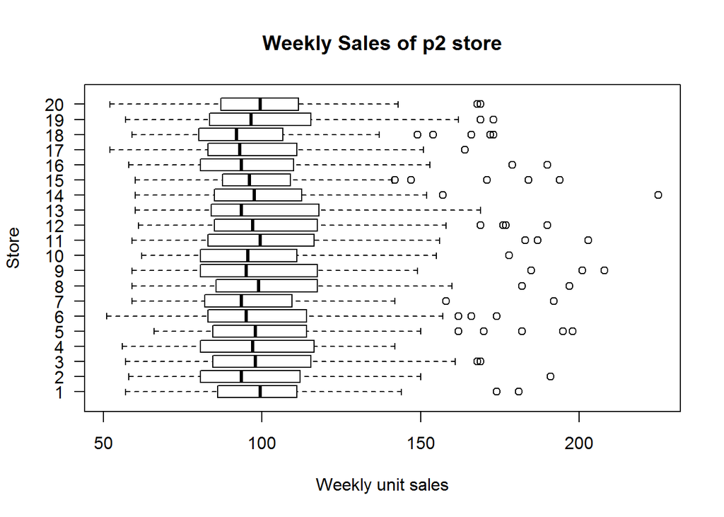

```r
boxplot(store.df$p2_sales ~ store.df$store_nbr,
                horizontal = T,
                ylab = "Store",
                xlab = "Weekly unit sales",
                las = 1,
                main = "Weekly Sales of p2 store")
```

[figure not shown]

```r
boxplot(p2_sales ~ p1_prom,
                data = store.df,
                horizontal = T,
                yaxt = "n",
                ylab = "p2 promoted in stores?",
                xlab = "Weekly Sales",
                main = "Weekly sales of p2 with and without promotion")

axis(side = 2, at = c(1,2), labels = c("No","yes"))
```

if we want to see the normality of the data, we can use a QQ plot

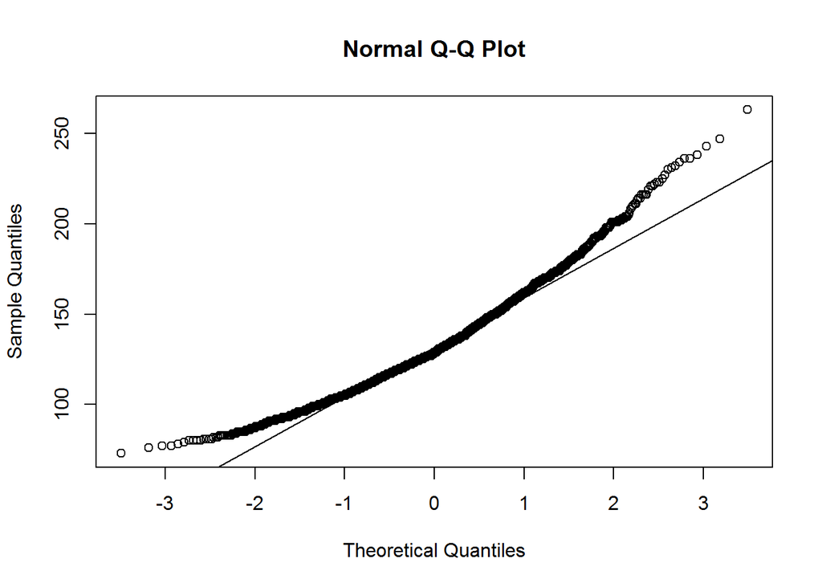

```r
qqnorm(store.df$p1_sales)
qqline(store.df$p1_sales)
```

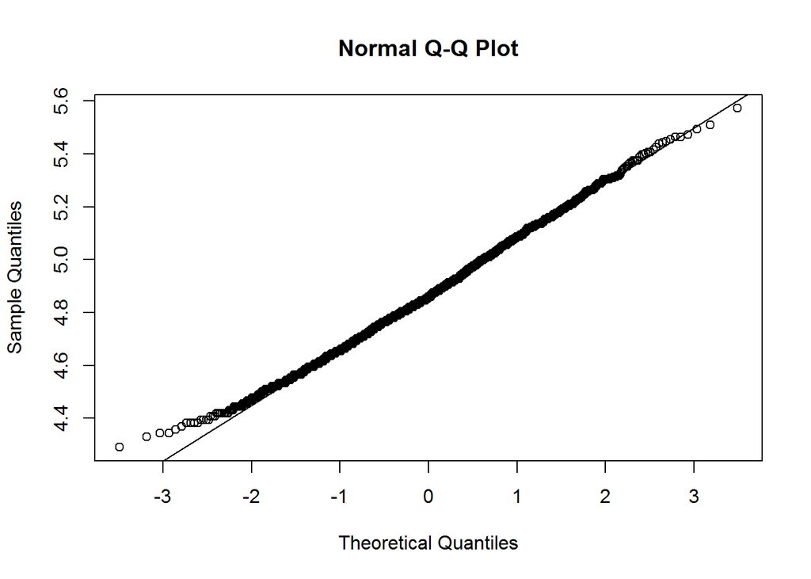

```r
# the upward corve is a given for ahighly sckewed adta

qqnorm(log(store.df$p1_sales))
qqline(log(store.df$p1_sales))
```

we can also use a empirical cumulative distribution function to view univarite data :D

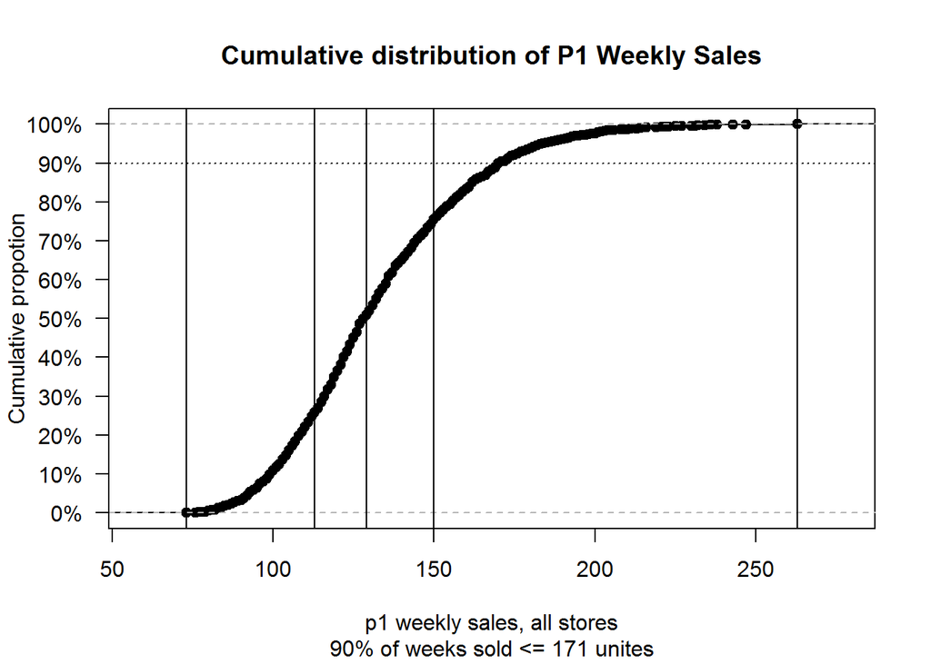

```r
plot(ecdf(store.df$p1_sales),
         main = "Cumulative distribution of P1 Weekly Sales",
         ylab = "Cumulative propotion",
         xlab = c("p1 weekly sales, all stores", "90% of weeks sold <= 171 unites"),
         yaxt = "n")

axis(side = 2,
         at = seq(0, 1, by = 0.1),
         las = 1,
         labels = paste(seq(0,100, by = 10), "%", sep = ""))

abline(h = 0.9, lty = 3) #h is for horizon at the 90th percentile
abline (v = quantile(store.df$p1_sales))
```

lets see a really cool map plot

```r
require(rworldmap)
require(RColorBrewer)
```

```r
p1_sales.sum = aggregate(store.df$p1_sales, by = list(country = store.df$country), sum)

#first we need to create a map ite
p1_sales.map = joinCountryData2Map(p1_sales.sum, joinCode = "ISO2", nameJoinColumn = "country")
```

```
## 7 codes from your data successfully matched countries in the map
## 0 codes from your data failed to match with a country code in the map
## 235 codes from the map weren't represented in your data
```

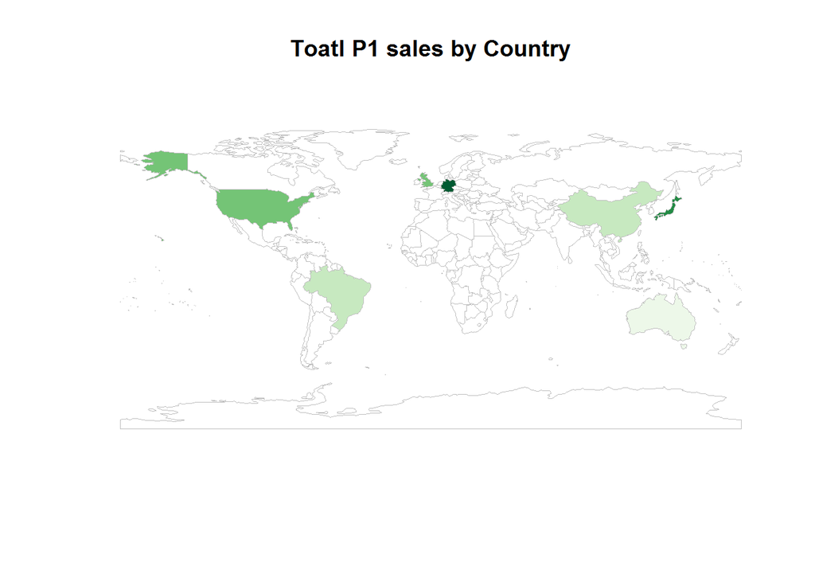

```r
#now we can plot

mapCountryData(p1_sales.map,
                             nameColumnToPlot = "x",
                             mapTitle = "Toatl P1 sales by Country",
                             colourPalette = brewer.pal(7, "Greens"),
                             catMethod = "fixedWodth",
                             addLegend = F)
```